# Climate Change Conversations Study 3

Ovidia Stanoi

08/24/2026

Study 3 examined how real-life conversation experiences related to willingness to talk more about climate change in the future. In a 10-day longitudinal study, 1,428 adult participants reported every other evening on their engagement in 10 climate-mitigating actions, including talking about climate change with other people. If participants reported having had at least one conversation in the last two days, we assessed whether or not they experienced three of the main facilitators identified in Study 2 during their conversations (increased motivation to take mitigating climate change action, emotional closeness, and feeling listened to) and four barriers (unpleasantness, lack of shared perspective, dismissal, and co-rumination). We additionally measured how pleasant the conversations were, as well as participants’ goals and their perception of these same goals in their conversation partner. Finally, participants indicated whether they would like to talk again about climate change with their conversation partner. This design allowed us to capture how different conversation experiences in daily life influence willingness to talk more about climate change in the future as well as actual conversation frequency.

Prepare data before running analyses.

```r
# Clear global environment
remove(list=ls())

# Open libraries
library("tidyverse")
library("knitr")
library("kableExtra")
library("reactable")
library("patchwork")
library("bmlm")
library("lme4")
library("broom.mixed")
library("ggforce")
library("sjPlot")
library("brms")
library("purrr")
library("marginaleffects")
library("bayestestR")
library("tidybayes")
library("arm")
library("modelbased")

# Set global options for rstanarm and brms models
options(mc.cores = parallel::detectCores())

# Set global ggplot theme
plot_aes = theme_minimal() +
  theme(legend.text = element_text(size = 8),
        text = element_text(size = 16),
        axis.text = element_text(color = "black"),
        axis.ticks.y = element_blank(),
        legend.position = "top",
        plot.title = element_text(hjust = 0.5),
        plot.title.position = "plot",
        panel.spacing.x = unit(1.5, "lines"),
        strip.text = element_text(size = 12),
        plot.margin = margin(t = 5, r = 5, b = 5, l = 5))

# Define colors
palette <- c("#67C5CA",  "#F18448", "#3B506E", "#7B2952",
             "#FFDD87","#00577C", "#262D63", "#21A48F",
             "#E0C831", "#1E2834", "#8FC25D", "#E52420")

# Define folder filedir
filedir <- "~/Dropbox/Psychology_Projects/Climate Change Conversations"

# Open datasets
d <- read_csv(sprintf("%s/Data/BB-Prime Longitudinal/study3_data_convo_experiences.csv", filedir))
d_goal <- read.csv(sprintf("%s/Data/BB-Prime Longitudinal/study3_data_goals.csv", filedir)) %>%
  dplyr::mutate(goal_match = factor(goal_match,
                                          levels = c("both_0", "self_1", "partner_1", "both_1")),
                goal_match_prev = factor(goal_match_prev,
                                          levels = c("both_0", "self_1", "partner_1", "both_1")))

# Create a function to extract posterior means, posterior standard deviations, 95% credible intervals,
# and probabilities of direction (pd) from Bayesian regression models
extract_brms_results <- function(model, model_label, predictor_labels) {

  # Extract posterior summary: mean, SD, and 95% credible interval
  results <- posterior_summary(model,
                               pars = "^b_",
                               probs = c(.025, .975))

  # Extract posterior draws
  draws <- as_draws_matrix(model)

  # Calculate probability of direction (pd)
  pd <- sapply(rownames(results), function(x) {
    d <- draws[, x]
    if (median(d) >= 0) {
      mean(d > 0)}
    else {
      mean(d < 0) }})

 # Remove "b_" prefix before matching predictor labels
  predictor_names <- sub("^b_", "", rownames(results))

  # Combine results
  data.frame(Model = model_label,
             Predictor = unname(predictor_labels[predictor_names]),
             `Posterior Mean` = results[, "Estimate"],
             `Posterior SD` = results[, "Est.Error"],
             Lower = results[, "Q2.5"],
             Upper = results[, "Q97.5"],
             PD = pd,
             check.names = FALSE)
}

# Create a function to obtain posterior predicted probabilities
predicted_values <- function(var, model) {

  # Create prediction data at the mean/reference values
  nd <- marginaleffects::datagrid(model = model)

  # Duplicate the first row so the predictors of interest can take two values
  nd <- dplyr::slice(nd, rep(1, 2))

  # We want to comapare predicted values of y for x = -0.5 vs. x = +0.5
  nd[[var]] <- c(-0.5, 0.5)

  # Obtain posterior expected probabilities
  posterior_epred(model,
                  newdata = nd,
                  re_formula = NA) %>%
    apply(2, quantile, probs = c(.025, .50, .975)) %>%
    t() %>%
    as.data.frame() %>%
    dplyr::mutate(value = c("No", "Yes"),
                  .before = 1) %>%
    dplyr::rename(lower = `2.5%`, prob = `50%`,  upper = `97.5%`)
}

# Create a function to calculate probabilities of direction
compute_pd <- function(model) {

  posterior::as_draws_df(model) %>%
    dplyr::select(dplyr::starts_with("b_")) %>%
    tidyr::pivot_longer(cols = everything(),
                        names_to = "var_name",
                        values_to = "draw") %>%
    dplyr::mutate(var_name = sub("^b_", "", var_name)) %>%
    dplyr::group_by(var_name) %>%
    dplyr::summarise(PD = max(mean(draw > 0), mean(draw < 0)),
                     .groups = "drop") %>%
    dplyr::mutate(high_pd = PD >= .975)
}


# Function to create prediction data for a model
prediction_data <- function(model, model_name, pred_var) {

  # Predicted probabilities
  predictions <- purrr::map_dfr(pred_var$var_name,
                                ~predicted_values(.x, model),
                                .id = "predictor_id") %>%
    dplyr::mutate(var_name = pred_var$var_name[as.integer(predictor_id)],
                  group_label = pred_var$group_label[as.integer(predictor_id)],
                  level_type = pred_var$level_type[as.integer(predictor_id)],
                  model = model_name) %>%
    dplyr::select(-predictor_id)

  # Probabilities of direction
  pd <- compute_pd(model)

  # Combine predictions and PDs
  predictions %>%
    dplyr::left_join(pd, by = "var_name")
}
```

# 1 Conversation Experiences

Research Question: **How do conversation experiences in daily life relate to intention to talk more about climate change in the future and frequency of climate change conversations?**

## Conversation Intention

Because the study included repeated measures within individuals, we used the `isolate()` function from the “bmlm” package to separate all variables that varied both between- and within-individuals into their respective subcomponents before including them in the model. This approach allowed us to disentangle time-varying within-person effects from stable between-individual differences.

We first examined how the presence of facilitators (motivated, close, listened to) and barriers (unpleasantness, lack of shared perspective, dismissal, and co-rumination) during conversations related to the likelihood of wanting to talk again. We tested these associations using a Bayesian multilevel logistic regression model with the default weakly informative priors. Both the within and between components of the predictors were included in the model and intercepts were allowed to vary across people. We also held constant several possible confounds: session number (1-5), baseline frequency of climate change conversations, age, gender, education, household income, and intervention group. The control arm (no intervention) was the group of reference.

```r
# m1 <- brm(convo_outcome_future_talk_more ~ convo_outcome_motivated_cw  +
#             convo_outcome_closer_cw +
#             convo_outcome_partner_response_listen_cw  +
#             convo_pleasant_cw +
#             convo_outcome_shared_reality_cw +
#             convo_outcome_partner_response_disintered_cw +
#             convo_outcome_partner_response_coruminate_cw +
#             convo_outcome_motivated_cb +
#             convo_outcome_closer_cb +
#             convo_outcome_partner_response_listen_cb +
#             convo_pleasant_cb +
#             convo_outcome_shared_reality_cb +
#             convo_outcome_partner_response_disintered_cb +
#             convo_outcome_partner_response_coruminate_cb +
#             action_current_c + age_c + gender_c + ses_degree_c +
#             ses_income_household_c + politics_ideology_c +
#             session_c + group + (1 | SID),
#             family = bernoulli(link = "logit"),  data = d, seed = 123)
```

Create a table of results, including posterior means, posterior standard deviations, 95% credible intervals, and probabilities of direction (pd).

```r
# Clean predictors' labels
m1_labels <- c("Intercept" = "Intercept",
  "convo_outcome_motivated_cw" = "Motivated (w/in)",
  "convo_outcome_closer_cw" = "Close (w/in)",
  "convo_outcome_partner_response_listen_cw" = "Listened (w/in)",
  "convo_pleasant_cw" = "Pleasant (w/in)",
  "convo_outcome_shared_reality_cw" = "Shared-Persp (w/in)",
  "convo_outcome_partner_response_disintered_cw" = "Dismissed (w/in)",
  "convo_outcome_partner_response_coruminate_cw" = "Co-Ruminated (w/in)",
  "convo_outcome_motivated_cb" = "Motivated (btw)",
  "convo_outcome_closer_cb" = "Close (btw)",
  "convo_outcome_partner_response_listen_cb" = "Listened (btw)",
  "convo_pleasant_cb" =  "Pleasant (btw)",
  "convo_outcome_shared_reality_cb" = "Shared-Persp (btw)",
  "convo_outcome_partner_response_disintered_cb" = "Dismissed (btw)",
  "convo_outcome_partner_response_coruminate_cb" = "Co-Ruminated (btw)",
  "action_current_c" = "Baseline Convo Freq",
  "age_c" = "Age",
  "gender_c" = "Gender",
  "ses_degree_c" = "Education",
  "ses_income_household_c" =  "HH Income",
  "politics_ideology_c" = "Political Orientation",
  "session_c" = "Time Point",
  "groupES_prevention_self" = "Intervention 1",
  "groupMCII_collective" = "Intervention 2",
  "groupSTPB" = "Intervention 3")

# Extract posterior means, posterior standard deviations, 95% credible intervals,
# and probabilities of direction (pd) from the model
m1_results <- extract_brms_results(model = m1,
                                   model_label = "Conversation intention",
                                   predictor_labels = m1_labels)

# Create results table
intention_table <- m1_results %>%
  dplyr::mutate(`Posterior Mean` = sprintf("%.2f", `Posterior Mean`),
                `Posterior SD` = sprintf("%.2f", `Posterior SD`),
                `95% CI` = sprintf("[%.2f, %.2f]", Lower, Upper),
                PD = sprintf("%.3f", PD))  %>%
  dplyr::select(Predictor, `Posterior Mean`, `Posterior SD`, `95% CI`, PD)

# Kable table
kable_output <- kable(intention_table,
      format = "html",
      row.names = FALSE,
      col.names = c("Predictor", "Posterior Mean", "Posterior SD", "95% CI", "PD"),
      align = c("l", "c", "c", "c", "c")) %>%
  kable_styling(bootstrap_options = "striped",
                full_width = FALSE,
                font_size = 12) %>%
  row_spec(0, bold = TRUE)

#  Save as a PDF file
save_kable(kable_output, sprintf("%s/Tables/study3_convo_experiences_intention.pdf", filedir))

#  See results.
kable_output
```

| Predictor | Posterior Mean | Posterior SD | 95% CI | PD |
| --- | --- | --- | --- | --- |
| Intercept | -0.58 | 0.12 | [-0.82, -0.35] | 1.000 |
| Motivated (w/in) | 0.40 | 0.13 | [0.14, 0.66] | 0.999 |
| Close (w/in) | 0.30 | 0.13 | [0.05, 0.55] | 0.990 |
| Listened (w/in) | 0.25 | 0.12 | [0.02, 0.48] | 0.985 |
| Pleasant (w/in) | -0.10 | 0.16 | [-0.42, 0.21] | 0.735 |
| Shared-Persp (w/in) | 0.10 | 0.12 | [-0.14, 0.34] | 0.799 |
| Dismissed (w/in) | -0.27 | 0.25 | [-0.77, 0.22] | 0.846 |
| Co-Ruminated (w/in) | -0.25 | 0.21 | [-0.65, 0.15] | 0.877 |
| Motivated (btw) | 1.82 | 0.20 | [1.44, 2.21] | 1.000 |
| Close (btw) | 0.90 | 0.20 | [0.51, 1.31] | 1.000 |
| Listened (btw) | 1.64 | 0.20 | [1.24, 2.03] | 1.000 |
| Pleasant (btw) | 0.03 | 0.18 | [-0.33, 0.40] | 0.566 |
| Shared-Persp (btw) | 0.36 | 0.19 | [-0.02, 0.73] | 0.968 |
| Dismissed (btw) | 0.43 | 0.39 | [-0.34, 1.19] | 0.863 |
| Co-Ruminated (btw) | 0.40 | 0.27 | [-0.15, 0.91] | 0.926 |
| Baseline Convo Freq | 0.04 | 0.03 | [-0.02, 0.11] | 0.907 |
| Age | 0.00 | 0.01 | [-0.01, 0.01] | 0.796 |
| Gender | -0.01 | 0.13 | [-0.27, 0.24] | 0.546 |
| Education | 0.01 | 0.05 | [-0.09, 0.10] | 0.555 |
| HH Income | -0.06 | 0.03 | [-0.13, 0.01] | 0.954 |
| Political Orientation | -0.05 | 0.03 | [-0.11, 0.02] | 0.914 |
| Time Point | 0.14 | 0.03 | [0.07, 0.20] | 1.000 |
| Intervention 1 | 0.08 | 0.18 | [-0.29, 0.43] | 0.666 |
| Intervention 2 | 0.37 | 0.17 | [0.04, 0.70] | 0.986 |
| Intervention 3 | 0.09 | 0.17 | [-0.25, 0.43] | 0.694 |

Create a figure showing the predicted probability of wanting to talk more when different conversation experiences were present or not.

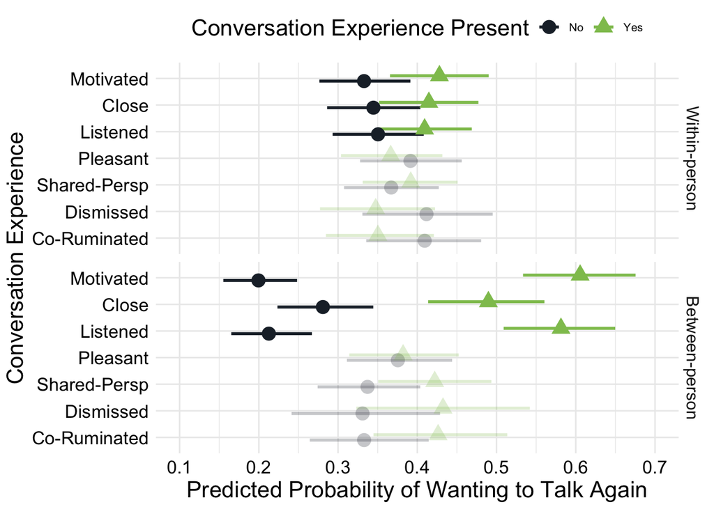

```r
# Select predictors to plot
pred_var <- tibble::tribble(~var_name, ~group_label, ~level_type,

                             # Within-person predictors
                             "convo_outcome_motivated_cw", "Motivated", "Within-person",
                             "convo_outcome_closer_cw", "Close", "Within-person",
                             "convo_outcome_partner_response_listen_cw", "Listened", "Within-person",
                             "convo_pleasant_cw", "Pleasant", "Within-person",
                             "convo_outcome_shared_reality_cw", "Shared-Persp", "Within-person",
                             "convo_outcome_partner_response_disintered_cw", "Dismissed", "Within-person",
                             "convo_outcome_partner_response_coruminate_cw", "Co-Ruminated", "Within-person",

                             # Between-person predictors
                             "convo_outcome_motivated_cb", "Motivated", "Between-person",
                             "convo_outcome_closer_cb", "Close", "Between-person",
                             "convo_outcome_partner_response_listen_cb", "Listened", "Between-person",
                             "convo_pleasant_cb", "Pleasant", "Between-person",
                             "convo_outcome_shared_reality_cb", "Shared-Persp", "Between-person",
                             "convo_outcome_partner_response_disintered_cb", "Dismissed", "Between-person",
                             "convo_outcome_partner_response_coruminate_cb", "Co-Ruminated", "Between-person")

# Create prediction data
pred_val_final <- prediction_data(m1, "Conversation Intention", pred_var) %>%
  dplyr::mutate(group_label = factor(group_label,
                         levels = rev(unique(pred_var$group_label))),
                level_type = factor(level_type,
                                    levels = c("Within-person", "Between-person")),
                value = factor(value,
                               levels = c("No", "Yes")))

# Create figure
p_intention <- ggplot(pred_val_final, aes(x = prob, y = group_label,
                                  color = value, shape = value)) +
  geom_pointrange(aes(xmin = lower, xmax = upper, alpha = high_pd),
                  position = position_dodge(width = .4),
                  linewidth = 1, size = 1) +
  scale_color_manual(name = "Conversation Experience Present",
                     values = c("No" = palette[10], "Yes" = palette[11])) +
  scale_shape_manual(name = "Conversation Experience Present",
                     values = c("No" = 16, "Yes" = 17)) +
  scale_alpha_manual(values = c( "TRUE" = 1, "FALSE" = .25),
                     guide = "none") +
  labs(x = "Predicted Probability of Wanting to Talk Again",
       y = "Conversation Experience") +
  facet_grid(level_type ~ ., scales = "free_y", space = "free_y") +
  guides(color = guide_legend(title = "Conversation Experience Present"),
         shape = guide_legend(title = "Conversation Experience Present")) +
  scale_x_continuous(limits = c(0.1, 0.7), breaks = c(0.1, 0.2, 0.3, 0.4, 0.5, 0.6, 0.7)) +
  plot_aes

# Save figure
{ragg::agg_tiff(sprintf("%s/Figures/study3_convo_experiences_intention.tiff", filedir),
               width = 1800, height = 1500,
               units = "px", res = 300)
  print(p_intention)
  invisible(dev.off())}

# See figure
p_intention
```

## Conversation Likelihood

We fit two Bayesian multilevel logistic regression models to examine whether conversation experiences were associated with (1) the likelihood of reporting another conversation at the subsequent time point (within-person) and (2) the likelihood of reporting any conversation during the study period (between-person). The models were estimated separately to allow the between-person model to include all study observations, including participants’ first conversations. We allowed intercepts to vary across people. We also held constant several possible confounds: session number (1-5), baseline frequency of climate change conversations, age, gender, education, household income, and intervention group. The control arm (no intervention) was the group of reference.

```r
# # Run regression model testing longitudinal associations
# m2 <- brm(conversation ~ convo_outcome_motivated_prev_cw +
#             convo_outcome_closer_prev_cw +
#             convo_outcome_partner_response_listen_prev_cw  +
#             convo_pleasant_prev_cw +
#             convo_outcome_shared_reality_prev_cw +
#             convo_outcome_partner_response_disintered_prev_cw +
#             convo_outcome_partner_response_coruminate_prev_cw +
#             convo_outcome_motivated_cb +
#             convo_outcome_closer_cb +
#             convo_outcome_partner_response_listen_cb +
#             convo_pleasant_cb +
#             convo_outcome_shared_reality_cb +
#             convo_outcome_partner_response_disintered_cb +
#             convo_outcome_partner_response_coruminate_cb +
#             action_current_c + age_c + gender_c + ses_degree_c +
#             ses_income_household_c + politics_ideology_c +
#             session_c + group + (1 | SID),
#             family = bernoulli(link = "logit"), data = d, seed = 123)
#
# # Run regression model to test associations with between-individual differences
# # We need to run this model separately from the longitudinal one in order to be able to
# # include and count the first conversation of the study as well
# m2b <- brm(conversation ~ convo_outcome_motivated_cb +
#             convo_outcome_closer_cb +
#             convo_outcome_partner_response_listen_cb +
#             convo_pleasant_cb +
#             convo_outcome_shared_reality_cb +
#             convo_outcome_partner_response_disintered_cb +
#             convo_outcome_partner_response_coruminate_cb +
#             action_current_c + age_c + gender_c + ses_degree_c +
#             ses_income_household_c + politics_ideology_c +
#             session_c + group + (1 | SID),
#             family = bernoulli(link = "logit"), data = d, seed = 123)
```

Create a table of results, including posterior means, posterior standard deviations, 95% credible intervals, and probabilities of direction (pd).

```r
# Table showing results combined from two models:
# m2  = within-person model
# m2b = between-person model

# Clean labels of predictors to be extracted from the within-person model
m2_labels <- c("Intercept" = "Intercept",
               "convo_outcome_motivated_prev_cw" = "Motivated (w/in)",
               "convo_outcome_closer_prev_cw" = "Close (w/in)",
               "convo_outcome_partner_response_listen_prev_cw" = "Listened (w/in)",
               "convo_pleasant_prev_cw" = "Pleasant (w/in)",
               "convo_outcome_shared_reality_prev_cw" = "Shared-Persp (w/in)",
               "convo_outcome_partner_response_disintered_prev_cw" = "Dismissed (w/in)",
               "convo_outcome_partner_response_coruminate_prev_cw" = "Co-Ruminated (w/in)",
               "convo_outcome_motivated_cb" = "Motivated (btw)",
               "convo_outcome_closer_cb" = "Close (btw)",
               "convo_outcome_partner_response_listen_cb" = "Listened (btw)",
               "convo_pleasant_cb" = "Pleasant (btw)",
               "convo_outcome_shared_reality_cb" = "Shared-Persp (btw)",
               "convo_outcome_partner_response_disintered_cb" = "Dismissed (btw)",
               "convo_outcome_partner_response_coruminate_cb" = "Co-Ruminated (btw)",
               "action_current_c" = "Baseline Convo Freq",
               "age_c" = "Age",
               "gender_c" = "Gender",
               "ses_degree_c" = "Education",
               "ses_income_household_c" =  "HH Income",
               "politics_ideology_c" = "Political Orientation",
               "session_c" = "Time Point",
               "groupES_prevention_self" = "Intervention 1",
               "groupMCII_collective" = "Intervention 2",
               "groupSTPB" = "Intervention 3")


# Clean labels of predictors to be extracted from the between-person model
m2b_labels <- c("Intercept" = "Intercept",
               "convo_outcome_motivated_cb" = "Motivated (btw)",
               "convo_outcome_closer_cb" = "Close (btw)",
               "convo_outcome_partner_response_listen_cb" = "Listened (btw)",
               "convo_pleasant_cb" = "Pleasant (btw)",
               "convo_outcome_shared_reality_cb" = "Shared-Persp (btw)",
               "convo_outcome_partner_response_disintered_cb" = "Dismissed (btw)",
               "convo_outcome_partner_response_coruminate_cb" = "Co-Ruminated (btw)",
               "age_c" = "Age",
               "gender_c" = "Gender",
               "ses_degree_c" = "Education",
               "ses_income_household_c" =  "HH Income",
               "politics_ideology_c" = "Political Orientation",
               "session_c" = "Time Point",
               "groupES_prevention_self" = "Intervention 1",
               "groupMCII_collective" = "Intervention 2",
               "groupSTPB" = "Intervention 3")

# Extract posterior means, posterior standard deviations, 95% credible intervals,
# and probabilities of direction (pd) from the models
m2_results <- extract_brms_results(model = m2,
                                   model_label = "Longitudinal within-person",
                                   predictor_labels = m2_labels)

m2b_results <- extract_brms_results(model = m2b,
                                    model_label = "Between-person",
                                    predictor_labels = m2b_labels)


# Create a table of combined results
combined_results <- bind_rows(m2_results,
                              m2b_results) %>%
  mutate(`Posterior Mean` = sprintf("%.2f", `Posterior Mean`),
         `Posterior SD` = sprintf("%.2f", `Posterior SD`),
         `95% CI` = sprintf("[%.2f, %.2f]", Lower, Upper),
         PD = sprintf("%.3f", PD)) %>%
  dplyr::select(Model, Predictor, `Posterior Mean`, `Posterior SD`, `95% CI`, PD)

# Kable table
kable_output <- kable(combined_results,
                      format = "html",
                      row.names = FALSE,
                      col.names = c("Model", "Predictor", "Posterior Mean",
                                    "Posterior SD", "95% CI", "PD"),
                      align = c("l", "l", "c", "c", "c", "c")) %>%
  kable_styling(bootstrap_options = "striped",
                full_width = FALSE,
                font_size = 12) %>%
  row_spec(0, bold = TRUE)

# Save table as PDF
save_kable(kable_output, sprintf("%s/Tables/study3_conversation_experiences_freq.pdf",
                                 filedir))

# See table of results
kable_output
```

| Model | Predictor | Posterior Mean | Posterior SD | 95% CI | PD |
| --- | --- | --- | --- | --- | --- |
| Longitudinal within-person | Intercept | 2.67 | 0.28 | [2.17, 3.26] | 1.000 |
| Longitudinal within-person | Motivated (w/in) | -0.01 | 0.27 | [-0.55, 0.53] | 0.503 |
| Longitudinal within-person | Close (w/in) | -0.14 | 0.27 | [-0.67, 0.38] | 0.703 |
| Longitudinal within-person | Listened (w/in) | 0.09 | 0.22 | [-0.35, 0.53] | 0.646 |
| Longitudinal within-person | Pleasant (w/in) | -0.25 | 0.30 | [-0.84, 0.33] | 0.796 |
| Longitudinal within-person | Shared-Persp (w/in) | -0.15 | 0.24 | [-0.63, 0.31] | 0.736 |
| Longitudinal within-person | Dismissed (w/in) | 0.40 | 0.50 | [-0.57, 1.38] | 0.786 |
| Longitudinal within-person | Co-Ruminated (w/in) | 0.62 | 0.37 | [-0.08, 1.35] | 0.956 |
| Longitudinal within-person | Motivated (btw) | 3.28 | 0.42 | [2.50, 4.15] | 1.000 |
| Longitudinal within-person | Close (btw) | 0.82 | 0.37 | [0.09, 1.58] | 0.986 |
| Longitudinal within-person | Listened (btw) | 0.53 | 0.33 | [-0.11, 1.17] | 0.948 |
| Longitudinal within-person | Pleasant (btw) | 1.03 | 0.31 | [0.42, 1.67] | 0.999 |
| Longitudinal within-person | Shared-Persp (btw) | -0.04 | 0.32 | [-0.67, 0.59] | 0.560 |
| Longitudinal within-person | Dismissed (btw) | 0.24 | 0.63 | [-1.00, 1.50] | 0.649 |
| Longitudinal within-person | Co-Ruminated (btw) | -1.13 | 0.45 | [-2.03, -0.28] | 0.995 |
| Longitudinal within-person | Baseline Convo Freq | 0.36 | 0.06 | [0.24, 0.49] | 1.000 |
| Longitudinal within-person | Age | -0.02 | 0.01 | [-0.03, 0.00] | 0.959 |
| Longitudinal within-person | Gender | -0.37 | 0.23 | [-0.83, 0.07] | 0.947 |
| Longitudinal within-person | Education | 0.10 | 0.09 | [-0.06, 0.27] | 0.876 |
| Longitudinal within-person | HH Income | -0.02 | 0.06 | [-0.14, 0.10] | 0.610 |
| Longitudinal within-person | Political Orientation | 0.16 | 0.06 | [0.04, 0.28] | 0.995 |
| Longitudinal within-person | Time Point | 0.11 | 0.08 | [-0.04, 0.26] | 0.925 |
| Longitudinal within-person | Intervention 1 | 0.09 | 0.31 | [-0.51, 0.69] | 0.616 |
| Longitudinal within-person | Intervention 2 | -0.07 | 0.29 | [-0.63, 0.52] | 0.598 |
| Longitudinal within-person | Intervention 3 | -0.43 | 0.30 | [-1.05, 0.14] | 0.927 |
| Between-person | Intercept | 1.77 | 0.11 | [1.57, 2.00] | 1.000 |
| Between-person | Motivated (btw) | 1.77 | 0.17 | [1.45, 2.10] | 1.000 |
| Between-person | Close (btw) | 0.47 | 0.18 | [0.13, 0.82] | 0.997 |
| Between-person | Listened (btw) | 0.36 | 0.15 | [0.07, 0.66] | 0.991 |
| Between-person | Pleasant (btw) | 0.58 | 0.14 | [0.30, 0.85] | 1.000 |
| Between-person | Shared-Persp (btw) | -0.09 | 0.15 | [-0.39, 0.20] | 0.738 |
| Between-person | Dismissed (btw) | 0.10 | 0.28 | [-0.46, 0.65] | 0.632 |
| Between-person | Co-Ruminated (btw) | -0.30 | 0.21 | [-0.70, 0.11] | 0.928 |
| Between-person | NA | 0.30 | 0.03 | [0.24, 0.36] | 1.000 |
| Between-person | Age | -0.00 | 0.00 | [-0.01, 0.01] | 0.727 |
| Between-person | Gender | -0.13 | 0.11 | [-0.34, 0.09] | 0.875 |
| Between-person | Education | 0.07 | 0.04 | [-0.01, 0.15] | 0.966 |
| Between-person | HH Income | -0.02 | 0.03 | [-0.08, 0.03] | 0.793 |
| Between-person | Political Orientation | 0.12 | 0.03 | [0.06, 0.18] | 1.000 |
| Between-person | Time Point | 0.12 | 0.03 | [0.06, 0.18] | 1.000 |
| Between-person | Intervention 1 | -0.13 | 0.15 | [-0.44, 0.15] | 0.808 |
| Between-person | Intervention 2 | 0.11 | 0.15 | [-0.18, 0.41] | 0.778 |
| Between-person | Intervention 3 | -0.09 | 0.15 | [-0.38, 0.21] | 0.722 |

Create a figure showing the predicted probability of having a conversation when different conversation experiences were present or not.

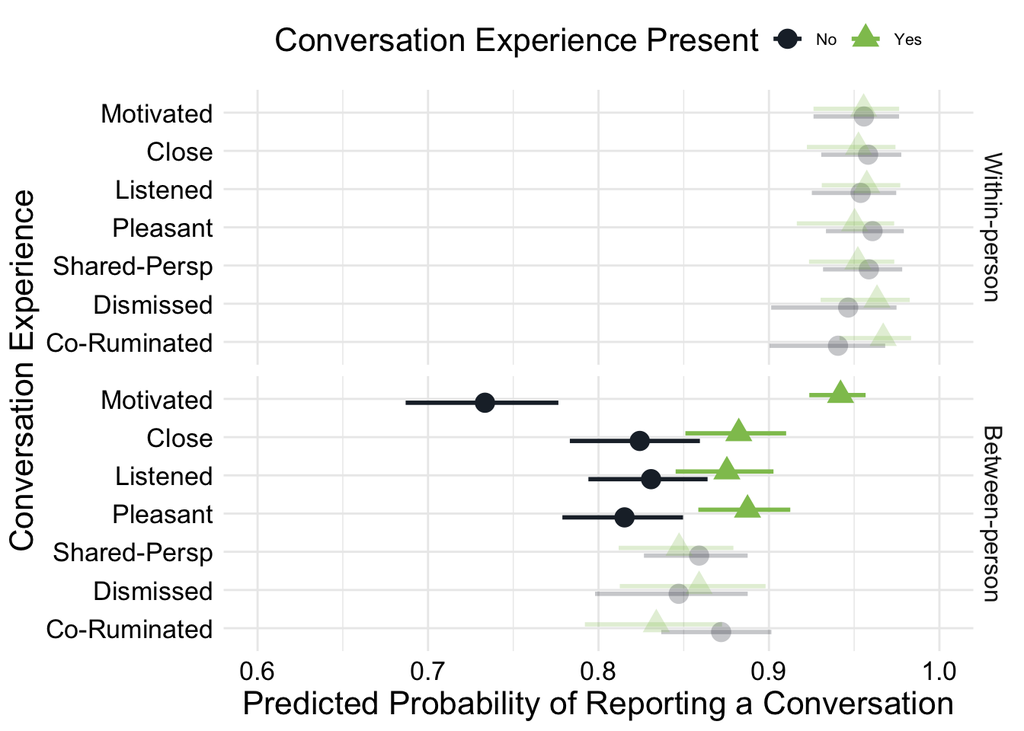

```r
# Select predictors to plot
pred_var_within <- tibble::tribble(~var_name, ~group_label, ~level_type,
                                   "convo_outcome_motivated_prev_cw", "Motivated", "Within-person",
                                   "convo_outcome_closer_prev_cw", "Close", "Within-person",
                                   "convo_outcome_partner_response_listen_prev_cw", "Listened", "Within-person",
                                   "convo_pleasant_prev_cw",  "Pleasant", "Within-person",
                                   "convo_outcome_shared_reality_prev_cw", "Shared-Persp", "Within-person",
                                   "convo_outcome_partner_response_disintered_prev_cw", "Dismissed", "Within-person",
                                   "convo_outcome_partner_response_coruminate_prev_cw", "Co-Ruminated", "Within-person")

pred_var_between <- tibble::tribble(~var_name, ~group_label, ~level_type,
                                    "convo_outcome_motivated_cb", "Motivated", "Between-person",
                                    "convo_outcome_closer_cb", "Close", "Between-person",
                                    "convo_outcome_partner_response_listen_cb", "Listened", "Between-person",
                                     "convo_pleasant_cb",  "Pleasant", "Between-person",
                                    "convo_outcome_shared_reality_cb",  "Shared-Persp", "Between-person",
                                    "convo_outcome_partner_response_disintered_cb", "Dismissed", "Between-person",
                                    "convo_outcome_partner_response_coruminate_cb", "Co-Ruminated", "Between-person")


# Create prediction data
pred_within <- prediction_data(model = m2,
                               model_name = "Within-person",
                               pred_var = pred_var_within)


pred_between <- prediction_data(model = m2b,
                                model_name = "Between-person",
                                pred_var = pred_var_between)


# Combine the two prediction datasets
pred_conversation <- dplyr::bind_rows(pred_within, pred_between) %>%
  dplyr::mutate(group_label = factor(group_label,
                                     levels = rev(c("Motivated", "Close", "Listened",
                                                    "Pleasant", "Shared-Persp",
                                                    "Dismissed", "Co-Ruminated"))),
    level_type = factor(level_type, levels = c("Within-person", "Between-person")),
    value = factor(value, levels = c("No", "Yes")))

# Create figure
p_conversation <- ggplot(pred_conversation,
  aes(x = prob, y = group_label, color = value, shape = value)) +
  geom_pointrange(aes(xmin = lower, xmax = upper, alpha = high_pd),
                  position = position_dodge(width = .4),
                  linewidth = 1,
                  size = 1) +
  scale_color_manual(name = "Conversation Experience Present",
                     values = c("No" = palette[10], "Yes" = palette[11])) +
  scale_shape_manual(name = "Conversation Experience Present",
                     values = c("No" = 16, "Yes" = 17)) +
  scale_alpha_manual(values = c("TRUE" = 1, "FALSE" = .25),
                     guide = "none") +
  labs(x = "Predicted Probability of Reporting a Conversation",
       y = "Conversation Experience") +
  facet_grid(level_type ~ ., scales = "free_y", space = "free_y") +
  guides(color = guide_legend(title = "Conversation Experience Present"),
         shape = guide_legend(title = "Conversation Experience Present")) +
  scale_x_continuous(limits = c(0.6, 1), breaks = c(0.6, 0.7, 0.8, 0.9, 1)) +
  plot_aes

# Save figure
{ragg::agg_tiff(sprintf("%s/Figures/study3_convo_experiences_freq.tiff", filedir),
               width = 1800, height = 1500,
               units = "px", res = 300)
  print(p_intention)
  invisible(dev.off())}


# See figure
p_conversation
```

## Figure 5

See below the script used to generate Figure 5 in the main manuscript.

```r
p_intention_final <- p_intention +
  labs(title = "Likelihood of wanting to talk more")

p_conversation_final <- p_conversation +
  labs(title = "Likelihood of having more conversations") +
  theme(axis.text.y = element_blank(),
        axis.ticks.y = element_blank(),
        axis.title.y = element_blank())

tiff(sprintf("%s/Figures/Figure 5. Study 3 Results Experiences.tiff", filedir),
     width = 14, height = 8, units = "in", res = 300, compression = "lzw")

wrap_plots(p_intention_final, p_conversation_final) +
  plot_layout(axis_titles = "collect", guides = "collect", ncol = 2) +
  plot_annotation(tag_levels = 'A', tag_suffix = '.') &
  theme(plot.tag = element_text(size = 20, face = "bold"),
        text = element_text(size = 18),
        plot.title = element_text(size = 19,
                                  hjust = 0.5, margin = margin(b = 15)),
        strip.text.y = element_text(size = 14),
        legend.position = "bottom",
        legend.title = element_text(size = 14),
        legend.text = element_text(size = 13),
        legend.key.size = grid::unit(0.8, "cm"),
        legend.spacing.x = grid::unit(0.4, "cm"),
        panel.grid.minor.x = element_blank(),
        panel.grid.minor.y = element_blank(),
        strip.background = element_rect(fill = "grey98",
                                        colour = "grey92",
                                        linewidth = 1),
        panel.spacing.y = grid::unit(1.5, "lines"),
        panel.border = element_rect(colour = "grey95",
                                    fill = NA, linewidth = 1))

invisible(dev.off())
```

# 2 Conversation Goals

Research Question: **How does goal alignment in conversations relate to intention to talk more about climate change in the future and frequency of climate change conversations?**

## Conversation Intention

We ran a Bayesian multilevel logistic regression model testing whether goal alignment during conversations predicts the likelihood of wanting to talk again with the conversation partner in the future. Goal alignment is represented by a factor variable called `goal_match` with four levels: neither person has the goal (both_0), only the partner has the goal (partner_1), only the participant has the goal (self_1), or both the participant and partner have the goal (both_1). The model includes as control variables: baseline conversation frequency, age, gender, education, household income, political orientation, time point, and intervention group. We allowed intercepts to vary across people to account for the nesting of repeated observations within participants. We also included random slopes for goal alignment for different types of goals (8 total: empower self, empower other, learn self, help other learn, connect, make a positive impression, feel less negative, make the other person feel less negative) to test whether the association between goal alignment and future conversation intention is specific to certain types of goals.

We examined only within-person associations because it was difficult to define between-person differences in average goal match levels for a categorical variable comprising of 8 goals with 4 possible match levels.

```r
# m3 <- brm(convo_outcome_future_talk_more ~ goal_match +
#             action_current_c + age_c + gender_c + ses_degree_c +
#             ses_income_household_c + politics_ideology_c +
#             session_c + group + (1 | SID) + (goal_match | goal_type),
#           family = bernoulli(link = "logit"),  data = d_goal,
#           seed = 123, iter = 10000)
```

Create a table of results, including posterior means, posterior standard deviations, 95% credible intervals, and probabilities of direction (pd) for both fixed effects and goal-specific slopes.

```r
# Labels for fixed effects
m3_labels <- c("Intercept" = "Intercept",
  "goal_matchself_1" = "Goal Alignment: Only Participant Has Goal",
  "goal_matchpartner_1" = "Goal Alignment: Only Convo Partner Has Goal",
  "goal_matchboth_1" = "Goal Alignment: Both Share Goal",
  "action_current_c" = "Baseline Convo Freq",
  "age_c" = "Age",
  "gender_c" = "Gender",
  "ses_degree_c" = "Education",
  "ses_income_household_c" = "HH Income",
  "politics_ideology_c" = "Political Orientation",
  "session_c" = "Time Point",
  "groupES_prevention_self" = "Intervention 1",
  "groupMCII_collective" = "Intervention 2",
  "groupSTPB" = "Intervention 3")


# Extract fixed effects' posterior means, posterior standard deviations,
# 95% credible intervals, and probabilities of direction (pd)
m3_fixed_results <- extract_brms_results(model = m3,
                                         model_label = "Fixed",
                                         predictor_labels = m3_labels) %>%
  dplyr::rename(Effects = Model) %>%
  dplyr::mutate(Predictor = factor(Predictor, levels = c("Intercept",
                                                         "Goal Alignment: Only Participant Has Goal",
                                                         "Goal Alignment: Only Convo Partner Has Goal",
                                                         "Goal Alignment: Both Share Goal",
                                                         "Baseline Convo Freq", "Age", "Gender",
                                                         "Education", "HH Income", "Political Orientation",
                                                         "Time Point", "Intervention 1", "Intervention 2",
                                                         "Intervention 3")),
                `Posterior Mean` = sprintf("%.2f", `Posterior Mean`),
                `Posterior SD` = sprintf("%.2f", `Posterior SD`),
                `95% CI` = sprintf("[%.2f, %.2f]", Lower, Upper),
                PD = sprintf("%.3f", PD)) %>%
  dplyr::arrange(Predictor) %>%
  dplyr::select(Effects, Predictor, `Posterior Mean`, `Posterior SD`, `95% CI`, PD)

# Extract goal-specific slopes' posterior means, posterior standard deviations,
# 95% credible intervals, and probabilities of direction (pd)
# Extract posterior draws for fixed effects + goal-type-specific random slopes
m3_random_results <- posterior::as_draws_df(m3) %>%
  dplyr::select(.draw, b_goal_matchpartner_1,
                b_goal_matchself_1,
                b_goal_matchboth_1,
                dplyr::starts_with("r_goal_type[")) %>%
  tidyr::pivot_longer(cols = dplyr::starts_with("r_goal_type["),
                      names_to = "Term",
                      values_to = "random_effect") %>%
  dplyr::filter(!grepl("Intercept", Term)) %>%
  dplyr::mutate(`Goal Type` = sub("^r_goal_type\\[([^,]+),.*$", "\\1", Term),
                `Goal Alignment` = sub("^r_goal_type\\[[^,]+,(.*)\\]$", "\\1", Term)) %>%
  dplyr::mutate(`Fixed Effect` = dplyr::case_when(`Goal Alignment` == "goal_matchpartner_1" ~ b_goal_matchpartner_1,
                                                  `Goal Alignment` == "goal_matchself_1" ~ b_goal_matchself_1,
                                                  `Goal Alignment` == "goal_matchboth_1" ~ b_goal_matchboth_1)) %>%
  dplyr::mutate(`Goal-Specific Effect` = `Fixed Effect` + random_effect) %>%
  dplyr::group_by(`Goal Type`, `Goal Alignment`) %>%
  dplyr::summarise(`Posterior Mean` = mean(`Goal-Specific Effect`),
                   `Posterior SD` = sd(`Goal-Specific Effect`),
                   Lower = quantile(`Goal-Specific Effect`, .025),
                   Upper = quantile(`Goal-Specific Effect`, .975),
                   PD = max(mean(`Goal-Specific Effect` > 0),
                            mean(`Goal-Specific Effect` < 0)),
                   .groups = "drop") %>%
  dplyr::mutate(`Posterior Mean` = sprintf("%.2f", `Posterior Mean`),
                `Posterior SD` = sprintf("%.2f", `Posterior SD`),
                `95% CI` = sprintf("[%.2f, %.2f]", Lower, Upper),
                PD = sprintf("%.3f", PD),
                `Goal Type` = factor(dplyr::recode(`Goal Type`,
                                                   "connect" = "Connect",
                                                   "pos_impression" = "Positive Impression",
                                                   "learn_participant" = "Learn (Self)",
                                                   "learn_convo_partner" = "Learn (Other)",
                                                   "empower_participant" = "Empower (Self)",
                                                   "empower_convo_partner" = "Empower (Other)",
                                                   "hedonic_participant" = "Hedonic (Self)",
                                                   "hedonic_convo_partner" = "Hedonic (Other)"),
                                     levels = c("Empower (Self)", "Empower (Other)",
                                                "Learn (Self)", "Learn (Other)",
                                                "Connect", "Positive Impression",
                                                "Hedonic (Self)", "Hedonic (Other)")),
                `Goal Alignment` = factor(dplyr::recode(`Goal Alignment`,
                                                        "goal_matchpartner_1" = "Only Convo Partner Has Goal",
                                                        "goal_matchself_1" = "Only Participant Has Goal",
                                                        "goal_matchboth_1" = "Both Share Goal"),
                                          levels = c("Only Participant Has Goal",
                                                     "Only Convo Partner Has Goal",
                                                     "Both Share Goal")),
                Effects = "Goal-specific") %>%
  dplyr::arrange(`Goal Type`, `Goal Alignment`) %>%
  dplyr::select(Effects, `Goal Type`, `Goal Alignment`, `Posterior Mean`,
                `Posterior SD`, `95% CI`, PD)

# Kable tables separately
kable_fixed_results <- kable(m3_fixed_results,
                             format = "html",
                             row.names = FALSE,
                             col.names = c("Effects", "Predictor", "Posterior Mean",
                                           "Posterior SD", "95% CI", "PD"),
                             align = c("l", "l", "c", "c", "c", "c")) %>%
  kable_styling(bootstrap_options = "striped",
                full_width = FALSE,
                font_size = 12) %>%
  row_spec(0, bold = TRUE)

kable_random_results <- kable(m3_random_results,
                             format = "html",
                             row.names = FALSE,
                             col.names = c("Effects", "Goal Type", "Goal Alignment" ,
                                           "Posterior Mean", "Posterior SD",
                                           "95% CI", "PD"),
                             align = c("l", "l", "l", "c", "c", "c", "c")) %>%
  kable_styling(bootstrap_options = "striped",
                full_width = FALSE,
                font_size = 12) %>%
  row_spec(0, bold = TRUE)

# Save tables as PDFs
save_kable(kable_fixed_results, sprintf("%s/Tables/study3_conversation_goal_alignment_intention_fixed.pdf",
                                 filedir))

save_kable(kable_random_results, sprintf("%s/Tables/study3_conversation_goal_alignment_intention_random.pdf",
                                 filedir))

# See table of results - fixed effects
kable_fixed_results
```

| Effects | Predictor | Posterior Mean | Posterior SD | 95% CI | PD |
| --- | --- | --- | --- | --- | --- |
| Fixed | Intercept | -2.52 | 0.34 | [-3.20, -1.85] | 1.000 |
| Fixed | Goal Alignment: Only Participant Has Goal | 0.19 | 0.07 | [0.05, 0.33] | 0.993 |
| Fixed | Goal Alignment: Only Convo Partner Has Goal | 0.25 | 0.07 | [0.11, 0.40] | 0.999 |
| Fixed | Goal Alignment: Both Share Goal | 0.53 | 0.10 | [0.33, 0.75] | 1.000 |
| Fixed | Baseline Convo Freq | 0.46 | 0.09 | [0.28, 0.65] | 1.000 |
| Fixed | Age | -0.00 | 0.01 | [-0.03, 0.02] | 0.616 |
| Fixed | Gender | -0.04 | 0.39 | [-0.80, 0.72] | 0.536 |
| Fixed | Education | 0.35 | 0.14 | [0.07, 0.62] | 0.994 |
| Fixed | HH Income | -0.09 | 0.10 | [-0.28, 0.10] | 0.834 |
| Fixed | Political Orientation | -0.02 | 0.10 | [-0.21, 0.16] | 0.597 |
| Fixed | Time Point | 0.22 | 0.01 | [0.19, 0.24] | 1.000 |
| Fixed | Intervention 1 | 0.49 | 0.52 | [-0.50, 1.50] | 0.827 |
| Fixed | Intervention 2 | 1.00 | 0.50 | [0.04, 2.02] | 0.979 |
| Fixed | Intervention 3 | 0.66 | 0.50 | [-0.31, 1.68] | 0.911 |

```r
# See table of results - random slopes
kable_random_results
```

| Effects | Goal Type | Goal Alignment | Posterior Mean | Posterior SD | 95% CI | PD |
| --- | --- | --- | --- | --- | --- | --- |
| Goal-specific | Empower (Self) | Only Participant Has Goal | 0.20 | 0.10 | [0.00, 0.40] | 0.977 |
| Goal-specific | Empower (Self) | Only Convo Partner Has Goal | 0.24 | 0.10 | [0.03, 0.42] | 0.983 |
| Goal-specific | Empower (Self) | Both Share Goal | 0.77 | 0.14 | [0.51, 1.06] | 1.000 |
| Goal-specific | Empower (Other) | Only Participant Has Goal | 0.24 | 0.10 | [0.07, 0.47] | 0.997 |
| Goal-specific | Empower (Other) | Only Convo Partner Has Goal | 0.25 | 0.09 | [0.06, 0.44] | 0.990 |
| Goal-specific | Empower (Other) | Both Share Goal | 0.57 | 0.11 | [0.37, 0.79] | 1.000 |
| Goal-specific | Learn (Self) | Only Participant Has Goal | 0.24 | 0.10 | [0.05, 0.47] | 0.994 |
| Goal-specific | Learn (Self) | Only Convo Partner Has Goal | 0.28 | 0.09 | [0.11, 0.48] | 0.999 |
| Goal-specific | Learn (Self) | Both Share Goal | 0.68 | 0.12 | [0.47, 0.94] | 1.000 |
| Goal-specific | Learn (Other) | Only Participant Has Goal | 0.24 | 0.10 | [0.07, 0.47] | 0.996 |
| Goal-specific | Learn (Other) | Only Convo Partner Has Goal | 0.27 | 0.09 | [0.08, 0.46] | 0.996 |
| Goal-specific | Learn (Other) | Both Share Goal | 0.54 | 0.11 | [0.34, 0.76] | 1.000 |
| Goal-specific | Connect | Only Participant Has Goal | 0.18 | 0.10 | [-0.02, 0.37] | 0.962 |
| Goal-specific | Connect | Only Convo Partner Has Goal | 0.26 | 0.09 | [0.09, 0.45] | 0.997 |
| Goal-specific | Connect | Both Share Goal | 0.49 | 0.12 | [0.26, 0.72] | 1.000 |
| Goal-specific | Positive Impression | Only Participant Has Goal | 0.15 | 0.10 | [-0.08, 0.32] | 0.920 |
| Goal-specific | Positive Impression | Only Convo Partner Has Goal | 0.26 | 0.09 | [0.08, 0.44] | 0.995 |
| Goal-specific | Positive Impression | Both Share Goal | 0.54 | 0.12 | [0.30, 0.79] | 1.000 |
| Goal-specific | Hedonic (Self) | Only Participant Has Goal | 0.14 | 0.10 | [-0.09, 0.31] | 0.904 |
| Goal-specific | Hedonic (Self) | Only Convo Partner Has Goal | 0.25 | 0.10 | [0.04, 0.45] | 0.986 |
| Goal-specific | Hedonic (Self) | Both Share Goal | 0.31 | 0.12 | [0.06, 0.54] | 0.992 |
| Goal-specific | Hedonic (Other) | Only Participant Has Goal | 0.15 | 0.10 | [-0.08, 0.32] | 0.919 |
| Goal-specific | Hedonic (Other) | Only Convo Partner Has Goal | 0.23 | 0.10 | [0.01, 0.41] | 0.980 |
| Goal-specific | Hedonic (Other) | Both Share Goal | 0.34 | 0.11 | [0.11, 0.56] | 0.998 |

For each of the eight goals, we combined the fixed and random effects to estimate the posterior predicted probability of wanting to talk again when: neither person has the goal, only the conversation partner has the goal, only the participant has the goal, or both people share the goal. We then calculated the difference in probabilities between these different scenarios. The results are summarized below using posterior mean and 95% credible intervals.

```r
# Extract posterior draws for fixed effects and random slopes
draws <- posterior::as_draws_df(m3) %>%
  dplyr::select(.draw, b_Intercept, b_goal_matchpartner_1,
                b_goal_matchself_1, b_goal_matchboth_1,
                dplyr::starts_with("r_goal_type[")) %>%
  tidyr::pivot_longer(cols = dplyr::starts_with("r_goal_type["),
                      names_to = "Term", values_to = "random_effect") %>%
  dplyr::filter(!grepl("Intercept", Term)) %>%
  dplyr::mutate(goal_type = sub("^r_goal_type\\[([^,]+),.*$", "\\1", Term),
                goal_match = sub("^r_goal_type\\[[^,]+,(.*)\\]$", "\\1", Term)) %>%
  dplyr::select(-Term) %>%
  tidyr::pivot_wider(names_from = goal_match,
                     values_from = random_effect,
                     names_prefix = "r_") %>%
  dplyr::mutate(b_partner1 = b_goal_matchpartner_1 + r_goal_matchpartner_1,
                b_self1 = b_goal_matchself_1 + r_goal_matchself_1,
                b_both1 = b_goal_matchboth_1 + r_goal_matchboth_1)

# Predict future intention for each level of goal alignment
pred <- draws %>%
  dplyr::mutate(pred_y_both0 = plogis(b_Intercept),
                pred_y_partner1 = plogis(b_Intercept + b_partner1),
                pred_y_self1 = plogis(b_Intercept + b_self1),
                pred_y_both1 = plogis(b_Intercept + b_both1),

                # Pairwise differences in predicted probability
                pred_y_diff_both1 = pred_y_both1 - pred_y_both0,
                pred_y_diff_partner1 = pred_y_partner1 - pred_y_both0,
                pred_y_diff_self1 = pred_y_self1 - pred_y_both0,
                pred_y_diff_both_self1 = pred_y_both1 - pred_y_self1,
                pred_y_diff_both_partner1 = pred_y_both1 - pred_y_partner1)


# Summarize predicted probabilities and pairwise differences
summary_results <- pred %>%
  tidyr::pivot_longer(cols = dplyr::starts_with("pred_y_"),
                      names_to = "condition",
                      values_to = "probability") %>%
  dplyr::group_by(goal_type, condition) %>%
  tidybayes::median_qi(probability, .width = 0.95) %>%
  dplyr::mutate(across(c(probability, .lower, .upper), ~ round(.x, 4)),
                       condition = dplyr::recode(condition,
                                          "pred_y_both0" = "Both No",
                                          "pred_y_partner1" = "Partner Only",
                                          "pred_y_self1" = "Self Only",
                                          "pred_y_both1" = "Both Yes",
                                          "pred_y_diff_both1" = "Est Diff Both-None",
                                          "pred_y_diff_partner1" = "Est Diff Convo Partner-None",
                                          "pred_y_diff_self1" = "Est Diff Participant-None",
                                          "pred_y_diff_both_self1" = "Est Diff Both-Participant",
                                          "pred_y_diff_both_partner1" = "Est Diff Both-Convo Partner")) %>%
  dplyr::select(goal_type, condition, probability, .lower, .upper) %>%
  dplyr::mutate(goal_type = factor(dplyr::recode(goal_type,
                                                 "empower_participant" = "Empower (Self)",
                                                 "empower_convo_partner" = "Empower (Other)",
                                                 "learn_participant" = "Learn (Self)",
                                                 "learn_convo_partner" = "Learn (Other)",
                                                 "connect" = "Connect",
                                                 "pos_impression" = "Positive Impression",
                                                 "hedonic_participant" = "Hedonic (Self)",
                                                 "hedonic_convo_partner" = "Hedonic (Other)"),
                                   levels = c("Empower (Self)", "Empower (Other)",
                                              "Learn (Self)", "Learn (Other)",
                                              "Connect", "Positive Impression",
                                              "Hedonic (Self)", "Hedonic (Other)")))  %>%
  dplyr::arrange(goal_type)

# Select only pairwise differences
summary_diff <- summary_results %>%
  filter(condition %in% c("Est Diff Both-None",
                          "Est Diff Convo Partner-None",
                          "Est Diff Participant-None",
                          "Est Diff Both-Participant",
                          "Est Diff Both-Convo Partner")) %>%
  mutate(`Posterior Mean` = sprintf("%.2f", probability),
                `95% CI` = sprintf("[%.2f, %.2f]", .lower, .upper)) %>%
  rename(Goal = goal_type, `Estimated Difference` = condition)  %>%
  dplyr::select(Goal, `Estimated Difference`, `Posterior Mean`, `95% CI`)

# Kable table
kable_output <- kable(summary_diff,
                      format = "html",
                      row.names = FALSE,
                      col.names = c("Goal", "Estimated Difference",
                                    "Posterior Mean", "95% CI"),
                      align = c("l", "l", "c", "c")) %>%
  kable_styling(bootstrap_options = "striped",
                full_width = FALSE,
                font_size = 12) %>%
  row_spec(0, bold = TRUE)

# Save table as PDF
save_kable(kable_output, sprintf("%s/Tables/study3_goal_pairwise_differences.pdf",
                                 filedir))

# See table of results
kable_output
```

| Goal | Estimated Difference | Posterior Mean | 95% CI |
| --- | --- | --- | --- |
| Empower (Self) | Est Diff Both-Convo Partner | 0.05 | [0.02, 0.11] |
| Empower (Self) | Est Diff Both-Participant | 0.06 | [0.02, 0.12] |
| Empower (Self) | Est Diff Both-None | 0.07 | [0.03, 0.14] |
| Empower (Self) | Est Diff Convo Partner-None | 0.02 | [0.00, 0.04] |
| Empower (Self) | Est Diff Participant-None | 0.01 | [0.00, 0.04] |
| Empower (Other) | Est Diff Both-Convo Partner | 0.03 | [0.01, 0.07] |
| Empower (Other) | Est Diff Both-Participant | 0.03 | [0.01, 0.07] |
| Empower (Other) | Est Diff Both-None | 0.05 | [0.02, 0.09] |
| Empower (Other) | Est Diff Convo Partner-None | 0.02 | [0.00, 0.04] |
| Empower (Other) | Est Diff Participant-None | 0.02 | [0.00, 0.05] |
| Learn (Self) | Est Diff Both-Convo Partner | 0.04 | [0.01, 0.09] |
| Learn (Self) | Est Diff Both-Participant | 0.04 | [0.02, 0.09] |
| Learn (Self) | Est Diff Both-None | 0.06 | [0.03, 0.12] |
| Learn (Self) | Est Diff Convo Partner-None | 0.02 | [0.01, 0.05] |
| Learn (Self) | Est Diff Participant-None | 0.02 | [0.00, 0.05] |
| Learn (Other) | Est Diff Both-Convo Partner | 0.03 | [0.00, 0.06] |
| Learn (Other) | Est Diff Both-Participant | 0.03 | [0.01, 0.06] |
| Learn (Other) | Est Diff Both-None | 0.05 | [0.02, 0.09] |
| Learn (Other) | Est Diff Convo Partner-None | 0.02 | [0.01, 0.05] |
| Learn (Other) | Est Diff Participant-None | 0.02 | [0.00, 0.05] |
| Connect | Est Diff Both-Convo Partner | 0.02 | [-0.00, 0.06] |
| Connect | Est Diff Both-Participant | 0.03 | [0.00, 0.07] |
| Connect | Est Diff Both-None | 0.04 | [0.02, 0.08] |
| Connect | Est Diff Convo Partner-None | 0.02 | [0.01, 0.04] |
| Connect | Est Diff Participant-None | 0.01 | [-0.00, 0.04] |
| Positive Impression | Est Diff Both-Convo Partner | 0.03 | [-0.00, 0.07] |
| Positive Impression | Est Diff Both-Participant | 0.04 | [0.01, 0.08] |
| Positive Impression | Est Diff Both-None | 0.05 | [0.02, 0.09] |
| Positive Impression | Est Diff Convo Partner-None | 0.02 | [0.00, 0.04] |
| Positive Impression | Est Diff Participant-None | 0.01 | [-0.01, 0.03] |
| Hedonic (Self) | Est Diff Both-Convo Partner | 0.01 | [-0.02, 0.04] |
| Hedonic (Self) | Est Diff Both-Participant | 0.01 | [-0.01, 0.04] |
| Hedonic (Self) | Est Diff Both-None | 0.02 | [0.00, 0.06] |
| Hedonic (Self) | Est Diff Convo Partner-None | 0.02 | [0.00, 0.04] |
| Hedonic (Self) | Est Diff Participant-None | 0.01 | [-0.01, 0.03] |
| Hedonic (Other) | Est Diff Both-Convo Partner | 0.01 | [-0.01, 0.04] |
| Hedonic (Other) | Est Diff Both-Participant | 0.02 | [-0.00, 0.05] |
| Hedonic (Other) | Est Diff Both-None | 0.03 | [0.01, 0.06] |
| Hedonic (Other) | Est Diff Convo Partner-None | 0.02 | [0.00, 0.04] |
| Hedonic (Other) | Est Diff Participant-None | 0.01 | [-0.01, 0.03] |

Finally, we plotted the predicted probability of wanting to talk again at the end of a conversation as a function of goal alignment. The predicted probability of wanting to talk again at the end of a conversation is presented on the y-axis as a function of whether or not a participant endorsed a given goal on the x-axis. The relationship between the two variables is estimated separately for when the conversation partner did not have the goal (black) and when it did (green). Points represent the estimated means of the posterior distributions and error bars indicate their 95% credible intervals. Panels show the results separately for each goal.

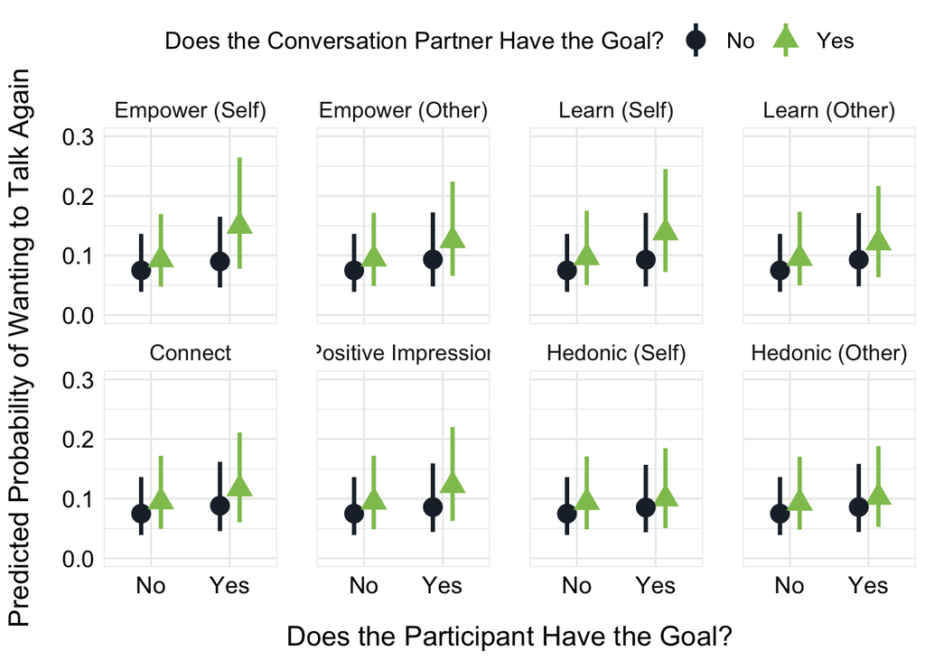

```r
# Create variables for plotting goal alignment
plot_data <- summary_results %>%
  dplyr::filter(!grepl("^Est Diff", condition)) %>%
  dplyr::mutate(participant_has_goal = dplyr::case_when(condition %in% c("Self Only", "Both Yes") ~ "Yes",
                                                        TRUE ~ "No"),
                partner_has_goal = dplyr::case_when(condition %in% c("Partner Only", "Both Yes") ~ "Yes",
                                                    TRUE ~ "No"))

# Plot predicted probabilities
p_goal_align <- ggplot(plot_data, aes(x = participant_has_goal, y = probability,
                                          color = partner_has_goal, shape = partner_has_goal)) +
  geom_pointrange(aes(ymin = .lower, ymax = .upper), size = 1.1, linewidth = 1.1,
                  position = position_dodge(width = 0.5)) +
  scale_color_manual(name = "Does the Conversation Partner Have the Goal?",
                     values = c("No" = palette[10], "Yes" = palette[11])) +
  scale_shape_manual(name = "Does the Conversation Partner Have the Goal?",
                     values = c("No" = 16, "Yes" = 17)) +
  labs(x = "Does the Participant Have the Goal?",
       y = "Predicted Probability of Wanting to Talk Again") +
  facet_wrap(~goal_type, ncol = 4) +
  scale_y_continuous(limits = c(0, 0.3), breaks = c(0,0.1, 0.2, 0.3)) +
  plot_aes +
  theme(panel.border = element_rect(color = "gray92", fill = NA,
                                    linewidth = 0.5),
        legend.title = element_text(size = 13),
        legend.text = element_text(size = 12),
        legend.key.size = grid::unit(0.8, "cm"),
        axis.title.y = element_text(size = 15, margin = margin(r = 15)),
        axis.title.x = element_text(size = 15, margin = margin(t = 15)))

# Save figure
{ragg::agg_tiff(sprintf("%s/Figures/Figure 6. Study 3 Results Goals.tiff", filedir),
                 width = 10, height = 5,
                units = "in", res = 600, compression = "lzw")
  print(p_goal_align)
  invisible(dev.off())}

# See figure
p_goal_align
```

## Conversation Likelihood

In a final analysis, we ran a Bayesian multilevel logistic regression model to see whether goal alignment during conversations predicts the likelihood of reporting a conversation at the next time point. Goal alignment is represented by a factor variable called `goal_match` with four levels: neither person has the goal (both_0), only the partner has the goal (partner_1), only the participant has the goal (self_1), or both the participant and partner have the goal (both_1). The model includes as control variables: baseline conversation frequency, age, gender, education, household income, political orientation, time point, and intervention group. We allowed intercepts to vary across people to account for the nesting of repeated observations within participants. We also included random slopes for goal alignment for different types of goals.

We examined only within-person associations because it was difficult to define between-person differences in average goal match levels for a categorical variable comprising of 8 goals with 4 possible match levels.

```r
# m4 <- brm(conversation ~ goal_match_prev +
#            action_current_c + age_c + gender_c + ses_degree_c +
#            ses_income_household_c + politics_ideology_c +
#            session_c + group + (1 | SID) +
#            (goal_match_prev | goal_type),
#            family = bernoulli(link = "logit"),
#          data = d_goal, seed = 123, iter = 10000)
```

Create a table of results, including posterior means, posterior standard deviations, 95% credible intervals, and probabilities of direction (pd) for both fixed effects and random slopes for each goal type.

```r
# Labels for fixed effects
m4_labels <- c("Intercept" = "Intercept",
               "goal_match_prevself_1" = "Goal Alignment: Only Participant Has Goal",
               "goal_match_prevpartner_1" = "Goal Alignment: Only Convo Partner Has Goal",
               "goal_match_prevboth_1" = "Goal Alignment: Both Share Goal",
               "action_current_c" = "Baseline Convo Freq",
               "age_c" = "Age",
               "gender_c" = "Gender",
               "ses_degree_c" = "Education",
               "ses_income_household_c" = "HH Income",
               "politics_ideology_c" = "Political Orientation",
               "session_c" = "Time Point",
               "groupES_prevention_self" = "Intervention 1",
               "groupMCII_collective" = "Intervention 2",
               "groupSTPB" = "Intervention 3")


# Extract fixed effects' posterior means, posterior standard deviations,
# 95% credible intervals, and probabilities of direction (pd)
m4_fixed_results <- extract_brms_results(model = m4,
                                         model_label = "Fixed",
                                         predictor_labels = m4_labels) %>%
  dplyr::rename(Effects = Model) %>%
  dplyr::mutate(Predictor = factor(Predictor, levels = c("Intercept",
                                                         "Goal Alignment: Only Participant Has Goal",
                                                         "Goal Alignment: Only Convo Partner Has Goal",
                                                         "Goal Alignment: Both Share Goal",
                                                         "Baseline Convo Freq", "Age", "Gender",
                                                         "Education", "HH Income", "Political Orientation",
                                                         "Time Point", "Intervention 1", "Intervention 2",
                                                         "Intervention 3")),
                `Posterior Mean` = sprintf("%.2f", `Posterior Mean`),
                `Posterior SD` = sprintf("%.2f", `Posterior SD`),
                `95% CI` = sprintf("[%.2f, %.2f]", Lower, Upper),
                PD = sprintf("%.3f", PD)) %>%
  dplyr::arrange(Predictor) %>%
  dplyr::select(Effects, Predictor, `Posterior Mean`, `Posterior SD`, `95% CI`, PD)

# Extract random slopes' posterior means, posterior standard deviations,
# 95% credible intervals, and probabilities of direction (pd)
# Extract posterior draws for fixed effects + goal-type-specific random slopes
m4_random_results <- posterior::as_draws_df(m4) %>%
  dplyr::select(.draw, b_goal_match_prevpartner_1,
                b_goal_match_prevself_1,
                b_goal_match_prevboth_1,
                dplyr::starts_with("r_goal_type[")) %>%
  tidyr::pivot_longer(cols = dplyr::starts_with("r_goal_type["),
                      names_to = "Term",
                      values_to = "random_effect") %>%
  dplyr::filter(!grepl("Intercept", Term)) %>%
  dplyr::mutate(`Goal Type` = sub("^r_goal_type\\[([^,]+),.*$", "\\1", Term),
                `Goal Alignment` = sub("^r_goal_type\\[[^,]+,(.*)\\]$", "\\1", Term)) %>%
  dplyr::mutate(`Fixed Effect` = dplyr::case_when(`Goal Alignment` == "goal_match_prevpartner_1" ~ b_goal_match_prevpartner_1,
                                                  `Goal Alignment` == "goal_match_prevself_1" ~ b_goal_match_prevself_1,
                                                  `Goal Alignment` == "goal_match_prevboth_1" ~ b_goal_match_prevboth_1)) %>%
  dplyr::mutate(`Goal-Specific Effect` = `Fixed Effect` + random_effect) %>%
  dplyr::group_by(`Goal Type`, `Goal Alignment`) %>%
  dplyr::summarise(`Posterior Mean` = mean(`Goal-Specific Effect`),
                   `Posterior SD` = sd(`Goal-Specific Effect`),
                   Lower = quantile(`Goal-Specific Effect`, .025),
                   Upper = quantile(`Goal-Specific Effect`, .975),
                   PD = max(mean(`Goal-Specific Effect` > 0),
                            mean(`Goal-Specific Effect` < 0)),
                   .groups = "drop") %>%
  dplyr::mutate(`Posterior Mean` = sprintf("%.2f", `Posterior Mean`),
                `Posterior SD` = sprintf("%.2f", `Posterior SD`),
                `95% CI` = sprintf("[%.2f, %.2f]", Lower, Upper),
                PD = sprintf("%.3f", PD),
                `Goal Type` = factor(dplyr::recode(`Goal Type`,
                                                   "connect" = "Connect",
                                                   "pos_impression" = "Positive Impression",
                                                   "learn_participant" = "Learn (Self)",
                                                   "learn_convo_partner" = "Learn (Other)",
                                                   "empower_participant" = "Empower (Self)",
                                                   "empower_convo_partner" = "Empower (Other)",
                                                   "hedonic_participant" = "Hedonic (Self)",
                                                   "hedonic_convo_partner" = "Hedonic (Other)"),
                                     levels = c("Empower (Self)", "Empower (Other)",
                                                "Learn (Self)", "Learn (Other)",
                                                "Connect", "Positive Impression",
                                                "Hedonic (Self)", "Hedonic (Other)")),
                `Goal Alignment` = factor(dplyr::recode(`Goal Alignment`,
                                                        "goal_match_prevpartner_1" = "Only Convo Partner Has Goal",
                                                        "goal_match_prevself_1" = "Only Participant Has Goal",
                                                        "goal_match_prevboth_1" = "Both Share Goal"),
                                          levels = c("Only Participant Has Goal",
                                                     "Only Convo Partner Has Goal",
                                                     "Both Share Goal")),
                Effects = "Goal-specific") %>%
  dplyr::arrange(`Goal Type`, `Goal Alignment`) %>%
  dplyr::select(Effects, `Goal Type`, `Goal Alignment`, `Posterior Mean`,
                `Posterior SD`, `95% CI`, PD)

# Kable tables separately
kable_fixed_results <- kable(m4_fixed_results,
                             format = "html",
                             row.names = FALSE,
                             col.names = c("Effects", "Predictor", "Posterior Mean",
                                           "Posterior SD", "95% CI", "PD"),
                             align = c("l", "l", "c", "c", "c", "c")) %>%
  kable_styling(bootstrap_options = "striped",
                full_width = FALSE,
                font_size = 12) %>%
  row_spec(0, bold = TRUE)

kable_random_results <- kable(m4_random_results,
                             format = "html",
                             row.names = FALSE,
                             col.names = c("Effects", "Goal Type", "Goal Alignment" ,
                                           "Posterior Mean", "Posterior SD",
                                           "95% CI", "PD"),
                             align = c("l", "l", "l", "c", "c", "c", "c")) %>%
  kable_styling(bootstrap_options = "striped",
                full_width = FALSE,
                font_size = 12) %>%
  row_spec(0, bold = TRUE)

# Save tables as PDFs
save_kable(kable_fixed_results, sprintf("%s/Tables/study3_conversation_goal_alignment_freq_fixed.pdf",
                                 filedir))

save_kable(kable_random_results, sprintf("%s/Tables/study3_conversation_goal_alignment_freq_random.pdf",
                                 filedir))

# See table of results - fixed effects
kable_fixed_results
```

| Effects | Predictor | Posterior Mean | Posterior SD | 95% CI | PD |
| --- | --- | --- | --- | --- | --- |
| Fixed | Intercept | 9.11 | 1.10 | [7.08, 11.38] | 1.000 |
| Fixed | Goal Alignment: Only Participant Has Goal | 0.19 | 0.17 | [-0.15, 0.52] | 0.872 |
| Fixed | Goal Alignment: Only Convo Partner Has Goal | 0.05 | 0.19 | [-0.33, 0.43] | 0.613 |
| Fixed | Goal Alignment: Both Share Goal | 0.20 | 0.22 | [-0.20, 0.66] | 0.851 |
| Fixed | Baseline Convo Freq | 2.30 | 0.33 | [1.69, 2.99] | 1.000 |
| Fixed | Age | -0.11 | 0.04 | [-0.20, -0.02] | 0.994 |
| Fixed | Gender | -1.46 | 1.11 | [-3.68, 0.69] | 0.914 |
| Fixed | Education | 1.23 | 0.41 | [0.45, 2.06] | 0.999 |
| Fixed | HH Income | 0.10 | 0.29 | [-0.47, 0.67] | 0.635 |
| Fixed | Political Orientation | 1.33 | 0.30 | [0.75, 1.95] | 1.000 |
| Fixed | Time Point | -0.44 | 0.04 | [-0.52, -0.36] | 1.000 |
| Fixed | Intervention 1 | -0.09 | 1.49 | [-3.02, 2.80] | 0.526 |
| Fixed | Intervention 2 | -0.95 | 1.43 | [-3.75, 1.83] | 0.746 |
| Fixed | Intervention 3 | -2.35 | 1.49 | [-5.33, 0.52] | 0.946 |

```r
# See table of results - random slopes
kable_random_results
```

| Effects | Goal Type | Goal Alignment | Posterior Mean | Posterior SD | 95% CI | PD |
| --- | --- | --- | --- | --- | --- | --- |
| Goal-specific | Empower (Self) | Only Participant Has Goal | 0.29 | 0.24 | [-0.13, 0.83] | 0.910 |
| Goal-specific | Empower (Self) | Only Convo Partner Has Goal | 0.10 | 0.25 | [-0.37, 0.66] | 0.661 |
| Goal-specific | Empower (Self) | Both Share Goal | 0.14 | 0.28 | [-0.42, 0.73] | 0.717 |
| Goal-specific | Empower (Other) | Only Participant Has Goal | 0.09 | 0.23 | [-0.42, 0.49] | 0.681 |
| Goal-specific | Empower (Other) | Only Convo Partner Has Goal | 0.19 | 0.29 | [-0.29, 0.90] | 0.748 |
| Goal-specific | Empower (Other) | Both Share Goal | 0.27 | 0.27 | [-0.20, 0.86] | 0.862 |
| Goal-specific | Learn (Self) | Only Participant Has Goal | 0.03 | 0.27 | [-0.60, 0.46] | 0.611 |
| Goal-specific | Learn (Self) | Only Convo Partner Has Goal | 0.16 | 0.22 | [-0.24, 0.65] | 0.757 |
| Goal-specific | Learn (Self) | Both Share Goal | 0.23 | 0.22 | [-0.18, 0.70] | 0.864 |
| Goal-specific | Learn (Other) | Only Participant Has Goal | 0.27 | 0.20 | [-0.08, 0.69] | 0.932 |
| Goal-specific | Learn (Other) | Only Convo Partner Has Goal | -0.09 | 0.26 | [-0.68, 0.34] | 0.611 |
| Goal-specific | Learn (Other) | Both Share Goal | 0.15 | 0.19 | [-0.22, 0.53] | 0.795 |
| Goal-specific | Connect | Only Participant Has Goal | 0.20 | 0.23 | [-0.26, 0.67] | 0.838 |
| Goal-specific | Connect | Only Convo Partner Has Goal | 0.02 | 0.22 | [-0.45, 0.44] | 0.551 |
| Goal-specific | Connect | Both Share Goal | 0.02 | 0.23 | [-0.48, 0.45] | 0.570 |
| Goal-specific | Positive Impression | Only Participant Has Goal | 0.10 | 0.26 | [-0.49, 0.56] | 0.687 |
| Goal-specific | Positive Impression | Only Convo Partner Has Goal | -0.08 | 0.28 | [-0.74, 0.40] | 0.580 |
| Goal-specific | Positive Impression | Both Share Goal | 0.68 | 0.53 | [-0.04, 1.91] | 0.961 |
| Goal-specific | Hedonic (Self) | Only Participant Has Goal | 0.26 | 0.21 | [-0.13, 0.70] | 0.907 |
| Goal-specific | Hedonic (Self) | Only Convo Partner Has Goal | 0.01 | 0.26 | [-0.56, 0.52] | 0.544 |
| Goal-specific | Hedonic (Self) | Both Share Goal | 0.10 | 0.24 | [-0.39, 0.57] | 0.690 |
| Goal-specific | Hedonic (Other) | Only Participant Has Goal | 0.25 | 0.22 | [-0.17, 0.72] | 0.891 |
| Goal-specific | Hedonic (Other) | Only Convo Partner Has Goal | 0.10 | 0.24 | [-0.35, 0.63] | 0.666 |
| Goal-specific | Hedonic (Other) | Both Share Goal | -0.00 | 0.24 | [-0.51, 0.42] | 0.524 |